# Data Science Final Project

# An Analysis of Movies from 2006-2016

## Team

- **Malio Mayo**

### Introduction

Movies have been a pivotal part of most people’s lives, whether it was a movie you saw as a kid that changed your view on the world, or a movie about a funny dinosaur that just made you laugh. Everyone loves a good movie, but what about the movie made it so great?

Asking the data these questions:

- Year with the most releases
- What movies did the best in this time period? Who directed them?
- What movies did the worst in this time period? Who directed them?
- How does IMDb’s rank of the movie for this segment of time compare to the rating?

To answer these questions:

- Does Genre affect how the movie does?
- Who (Director) makes the best movies?
- Who (Director) makes the worst movies?
- What was the Best rated movie of 2006-2016 based on the data?
- What was the Worst rated movie of 2006-2016 based on the data?
- Why is the IMDb Rank different than what the ratings say?

### Prerequisites

```r
library(tidyverse)
```

```r
library(ggplot2)
library (readr)
```

### Dataset

```r
urlfile="https://raw.githubusercontent.com/reisanar/datasets/master/IMDB_movies.csv"

IMDB<-read_csv(url(urlfile))
IMDB
```

```
## # A tibble: 1,000 x 12
##     Rank Title  Genre  Description Director Actors  Year `Runtime (Minut~ Rating
##    <dbl> <chr>  <chr>  <chr>       <chr>    <chr>  <dbl>            <dbl>  <dbl>
##  1     1 Guard~ Actio~ "A group o~ James G~ Chris~  2014              121    8.1
##  2     2 Prome~ Adven~ "Following~ Ridley ~ Noomi~  2012              124    7
##  3     3 Split  Horro~ "Three gir~ M. Nigh~ James~  2016              117    7.3
##  4     4 Sing   Anima~ "In a city~ Christo~ Matth~  2016              108    7.2
##  5     5 Suici~ Actio~ "A secret ~ David A~ Will ~  2016              123    6.2
##  6     6 The G~ Actio~ "European ~ Yimou Z~ Matt ~  2016              103    6.1
##  7     7 La La~ Comed~ "A jazz pi~ Damien ~ Ryan ~  2016              128    8.3
##  8     8 Mindh~ Comedy "A has-bee~ Sean Fo~ Essie~  2016               89    6.4
##  9     9 The L~ Actio~ "A true-li~ James G~ Charl~  2016              141    7.1
## 10    10 Passe~ Adven~ "A spacecr~ Morten ~ Jenni~  2016              116    7
## # ... with 990 more rows, and 3 more variables: Votes <dbl>,
## #   Revenue (Millions) <dbl>, Metascore <dbl>
```

### Data Analysis

#### Year with the most releases:

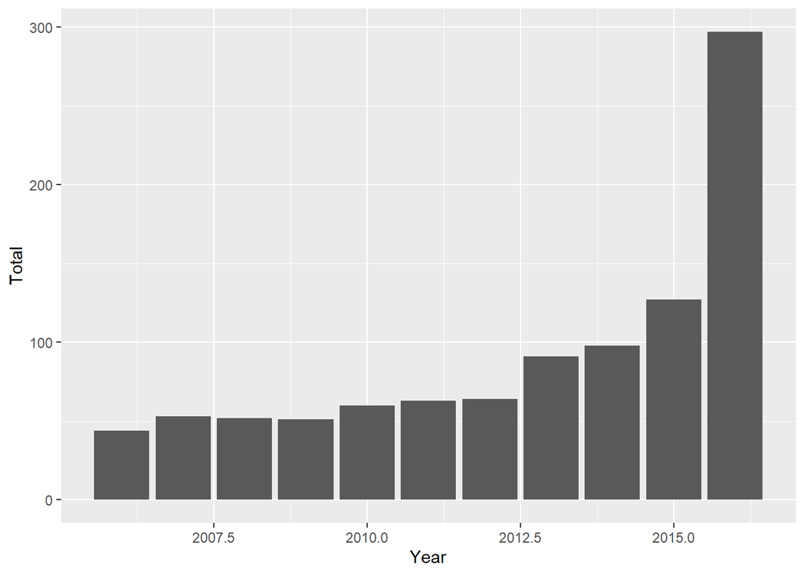

```r
IMDB %>%
  group_by(Year)%>%
  summarize(Total = n())%>%

ggplot() +
  geom_col(aes(x=Year, y = Total))
```

2016 had the most releases in this decade span of time.

#### Movies with the lowest ratings:

```r
IMDB %>%
  na.omit()%>%
  select(Title,Genre,Director,Rating)%>%
  arrange(Rating)%>%
  unique()
```

```
## # A tibble: 838 x 4
##    Title                                Genre                    Director Rating
##    <chr>                                <chr>                    <chr>     <dbl>
##  1 Disaster Movie                       Comedy                   Jason F~    1.9
##  2 Dragonball Evolution                 Action,Adventure,Fantasy James W~    2.7
##  3 The Disappointments Room             Drama,Horror,Thriller    D.J. Ca~    3.9
##  4 Birth of the Dragon                  Action,Biography,Drama   George ~    3.9
##  5 2307: Winter's Dream                 Sci-Fi                   Joey Cu~    4
##  6 Fifty Shades of Grey                 Drama,Romance,Thriller   Sam Tay~    4.1
##  7 Movie 43                             Comedy,Romance           Elizabe~    4.3
##  8 Fantastic Four                       Action,Adventure,Sci-Fi  Josh Tr~    4.3
##  9 Sex and the City 2                   Comedy,Drama,Romance     Michael~    4.3
## 10 The Human Centipede (First Sequence) Horror                   Tom Six     4.4
## # ... with 828 more rows
```

The worst movie made in the 2006-2016 Decade was Disaster Movie, Directed by Jason Friedberg and received a rating of 1.9.

#### Movies with the Best Ratings:

```r
IMDB %>%
  na.omit()%>%
  select(Title,Genre,Director,Rating)%>%
  arrange(desc(Rating))%>%
  unique()
```

```
## # A tibble: 838 x 4
##    Title                 Genre                   Director                 Rating
##    <chr>                 <chr>                   <chr>                     <dbl>
##  1 The Dark Knight       Action,Crime,Drama      Christopher Nolan           9
##  2 Inception             Action,Adventure,Sci-Fi Christopher Nolan           8.8
##  3 Interstellar          Adventure,Drama,Sci-Fi  Christopher Nolan           8.6
##  4 Kimi no na wa         Animation,Drama,Fantasy Makoto Shinkai              8.6
##  5 The Intouchables      Biography,Comedy,Drama  Olivier Nakache             8.6
##  6 The Prestige          Drama,Mystery,Sci-Fi    Christopher Nolan           8.5
##  7 The Departed          Crime,Drama,Thriller    Martin Scorsese             8.5
##  8 The Dark Knight Rises Action,Thriller         Christopher Nolan           8.5
##  9 Whiplash              Drama,Music             Damien Chazelle             8.5
## 10 The Lives of Others   Drama,Thriller          Florian Henckel von Don~    8.5
## # ... with 828 more rows
```

The Dark Knight was the highest rated movie in the 2006-2016 Time Span, its Director was Christopher Nolan and received a 9.0 rating.

#### Comparing IMDb’s Ranking to the Ratings

```r
IMDB %>%
  na.omit()%>%
  select(Title,Rank,Rating)%>%
  arrange((Rank))%>%
  unique()
```

```
## # A tibble: 838 x 3
##    Title                                    Rank Rating
##    <chr>                                   <dbl>  <dbl>
##  1 Guardians of the Galaxy                     1    8.1
##  2 Prometheus                                  2    7
##  3 Split                                       3    7.3
##  4 Sing                                        4    7.2
##  5 Suicide Squad                               5    6.2
##  6 The Great Wall                              6    6.1
##  7 La La Land                                  7    8.3
##  8 The Lost City of Z                          9    7.1
##  9 Passengers                                 10    7
## 10 Fantastic Beasts and Where to Find Them    11    7.5
## # ... with 828 more rows
```

The IMDb ranking system puts Guardians of the Galaxy as the number one movie with a rating of 8.1.

### Answering our Questions

The questions:

- Does Genre affect how the movie does?
- Who (Director) makes the best movies?
- Who (Director) makes the worst movies?
- What was the Best rated movie of 2006-2016 based on the data?
- What was the Worst rated movie of 2006-2016 based on the data?

#### Does Genre affect how the movie does?

According to the data, It does. Most of the movies in the top 20 have at least one of these listed as a genre: Action, Drama or Adventure. Which leads me to the conclusion that a movie that qualifies as an Action, Drama or Adventure movie will do better at the box office than other movies.

#### Who makes the best movies?

In the top 10 movies listed in the data, Christopher Nolan directed 5 of them. I think its safe to say that for the 2006-2016 Time Span, Christopher Nolan was the best Director.

#### Who makes the worst movies?

In the worst 50 movies rated in the 2006-2016 period, M. Night Shyamalan and Rob Cohen made 2 movies in the 50 worst rated movies, I would call that a tie for who made the worst movies in the 2006-2016 period.

#### What was the best rated movie in the 2006-2016 Time Span?

The best rated movie in the 2006-2016 Time Span was The Dark Night, Directed by Christopher Nolan, and was given a rating of 9.0.

#### What was the worst rated movie in the 2006-2016 Time Span?

The worst rated movie in the 2006-2016 Time Span was Disaster Movie, Directed by Jason Friedberg, and was given a rating of 1.9.

#### Why is the IMDb Rank different than what the ratings say?

The reason the IMDb rank is different than what the ratings say is because the movies are voted on by IMDb users and the ratings are universal. The difference in the rank and ratings, in my opinion, can be explained by the hype for the movie. I remember how hype I was for Guardians of the Galaxy to come out and it lived up to the hype.

### Conclusion

In conclusion, Christopher Nolan makes the best movies and Genre does matter in order for the movie to succeed.